# aLBI - A Simple R Package for Estimating Length-Based Indicators and Fish Stock Assessment from Length Frequency Data

Ataher Ali

2025-07-15

# aLBI: A Simple R Package for Fish Stock Assessment

## Introduction

The `aLBI` package provides tools for estimating life history parameters, length-based indicators, and assessing fish stock using methods outlined by Cope and Punt (2009) and Froese (2004). These methods are particularly useful in data-limited situations and for providing simple indicators to address over-fishing and support sustainable fisheries management. This simple package facilitates the estimation of life history parameters of fish only from the length frequency data. Version 0.1.8 introduces the `LWR` function for length-weight relationship analysis and updates `FrequencyTable` and `FsihPar` with enhanced functionality. These includes the addition Monte Carlo, non-parametric bootstrapping, and saving of outputs to the current working directory.

## Function Overview

### Methods

The package includes functions to calculate various length-based indicators and visualize fish stock data. The approaches from Cope and Punt (2009) are used to establish reference points, while Froese (2004)’s indicators help to evaluate over-fishing status. This vignette demonstrates how to use these functions with sample and provided data.

### Installation

To install the aLBI package from CRAN or GitHub. To enjoy most recent updates, users are encouraged to install the aLBI from GitHub), follow these steps. Note that devtools is required to install packages from GitHub.

```r
# You can install the package using the following commands in your R session:
# Install devtools if you haven't already
# install.packages("devtools")
# # Install dplyr if you haven't already
# install.packages("dplyr")
# # Install readxl if you haven't already
# install.packages("readxl")
# Install ggplot2 if you haven't already
# install.packages("ggplot2")
# Install openxlsx if you haven't already
# install.packages("openxlsx")
# install aLBI package from CRAN
# install.packages("aLBI")
# Install the most updated version of aLBI package from GitHub
# devtools::install_github("Ataher76/aLBI")
```

### Package Management

Ensure the required packages are loaded in your R session. The following code checks for package availability and stops execution with a message if a package is missing.

```r
# Check if required packages are installed and load them
# Check if required packages are installed and load them
required_packages <- c("aLBI", "readxl", "openxlsx", "dplyr", "devtools", "ggplot2")

for (pkg in required_packages) {
  if (!requireNamespace(pkg, quietly = TRUE)) {
    warning(paste("Package", pkg, "is required but not installed."))
  } else {
    library(pkg, character.only = TRUE)
  }
}
# Load the aLBI package
library(aLBI)
library(readxl)
library(dplyr)
library(ggplot2)
library(openxlsx)
library(devtools)
```

## Function (i): FrequencyTable

**FrequencyTable** function will generates the frequency table from the collected length data by calculated optimum bin size or user defined bin size. It also allows the user to provide Lmax from reliable sources such as **FishBase** or empirical studies. The function extract the length frequency data from the frequency table with the upper length_range and allow users to save the frequency data as an excel file for further use in the **FishPar** function.

### Arguments

- **data**: A numeric vector or data frame containing fish length measurements. If a data frame is provided, the first numeric column is used.
- **bin_width**: Optional. A numeric value specifying the bin width for class intervals, if left NULL or if not provided, the bin width is automatically calculated using Wang et al. (2020) optimum bin size (OBS) formula formula.

-**Lmax**: Optional. The maximum observed length of fish. Required only if `bin_width` is NULL and Wang’s formula is used. If not provided or left NULL then automatically calculate the frequency table with the observed maximum length of the provided data. - **output_file**: Optional. Character string specifying the output Excel file name. Defaults to “FrequencyTable_Output.xlsx”.

```r
library(readxl)
# Load your length data from the system file
lenfreq_path <- system.file("exdata", "ExData.xlsx", package = "aLBI")
print(lenfreq_path)  # Check the generated path
```

```
#> [1] "C:/Users/User/AppData/Local/Temp/RtmpE3BnKz/Rinst429445537cb6/aLBI/exdata/ExData.xlsx"
```

```r
if (lenfreq_path == "") {
  stop("The required file ExData.xlsx is missing. Please check the inst/extdata directory.")
}

# load the lenght frequency data
lenght_data <- readxl::read_excel(lenfreq_path)
print(lenght_data)  # check the
```

```
#> # A tibble: 1,177 × 1
#>    Length
#>     <dbl>
#>  1   75
#>  2   66.7
#>  3   66
#>  4   64
#>  5   63.3
#>  6   63.2
#>  7   62.3
#>  8   62.2
#>  9   62
#> 10   61.3
#> # ℹ 1,167 more rows
```

```r
# replace with your data directory
```

```r
# Running the FrequencyTable function
freqTable <- FrequencyTable(data = lenght_data, bin_width = NULL, Lmax = NULL, output_file = "FrequencyTable_Output.xlsx")
```

[output not shown]

```r
# Viewing the results
freqTable$lfqTable  # Display the frequency table
```

```
#> # A tibble: 21 × 2
#>    Length_Range Frequency
#>    <fct>            <int>
#>  1 [9,12)              15
#>  2 [12,15)             63
#>  3 [15,18)            135
#>  4 [18,21)            137
#>  5 [21,24)            135
#>  6 [24,27)            156
#>  7 [27,30)            143
#>  8 [30,33)             80
#>  9 [33,36)             88
#> 10 [36,39)             67
#> # ℹ 11 more rows
```

```r
freqTable$lfreq     # Display the summarized frequencies with upper length ranges
```

```
#> # A tibble: 21 × 2
#>    Length Frequency
#>     <dbl>     <int>
#>  1     12        15
#>  2     15        63
#>  3     18       135
#>  4     21       137
#>  5     24       135
#>  6     27       156
#>  7     30       143
#>  8     33        80
#>  9     36        88
#> 10     39        67
#> # ℹ 11 more rows
```

## Function (ii): FishPar

The **FishPar** function estimates life history parameters (e.g., Lmax, Linf, Lmat, and Lopt) using Monte Carlo Simulation and Froese Sustainability Indicators using non-parametric bootstrapping method.

### Arguments

- **data**: A data frame containing two columns: Length and Frequency.
- **resample**: An integer indicating the number of Monte Carlo samples or bootstrap resamples (default: 1000).
- **progress**: A logical value indicating whether to display a progress bar (default: FALSE).
- **Linf**: A numeric value for the asymptotic length (optional). If provided, overrides the default Lmax/0.95 calculation.
- **Linf_sd**: A numeric value for the standard deviation of random variation added to Linf (default: 0.5). Only used if Linf is provided.
- **Lmat**: A numeric value for the length at maturity (optional). If provided, overrides the default Monte Carlo estimation.
- **Lmat_sd**: A numeric value for the standard deviation of random variation added to Lmat (default: 0.5). Only used if Lmat is provided.

### Example with existing data

```r
library(readxl)
# Load your length-frequency data from the system file
lenfreq_path <- system.file("exdata", "LC.xlsx", package = "aLBI")
print(lenfreq_path)  # Check the generated path
```

```
#> [1] "C:/Users/User/AppData/Local/Temp/RtmpE3BnKz/Rinst429445537cb6/aLBI/exdata/LC.xlsx"
```

```r
if (lenfreq_path == "") {
  stop("The required file LC.xlsx is missing. Please check the inst/extdata directory.")
}

# load the lenght frequency data
lenfreq_data <- readxl::read_excel(lenfreq_path)
print(lenfreq_data)  # check the data
```

```
#> # A tibble: 15 × 2
#>    LengthClass Frequency
#>          <dbl>     <dbl>
#>  1          12        26
#>  2          15       166
#>  3          18       244
#>  4          21       582
#>  5          24       973
#>  6          27      1067
#>  7          30       963
#>  8          33       511
#>  9          36       472
#> 10          39       286
#> 11          42       173
#> 12          45       171
#> 13          48        83
#> 14          51        36
#> 15          54        36
```

```r
# replace with your data directory
```

```r
# Running the FishPar function
results <- FishPar(data = lenfreq_data, resample = 1000, progress = FALSE, Linf = NULL, Linf_sd = 0.5, Lmat = NULL, Lmat_sd = 0.5)
```

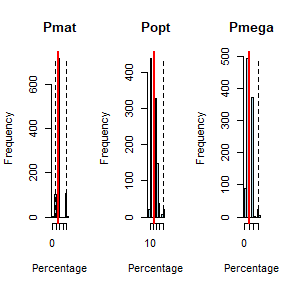

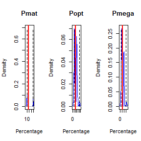

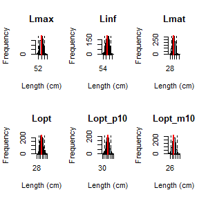

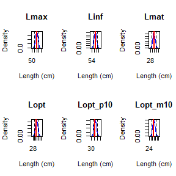

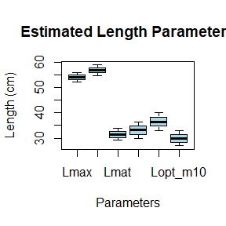

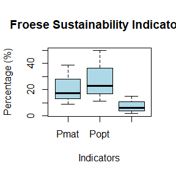

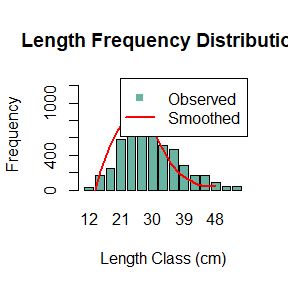

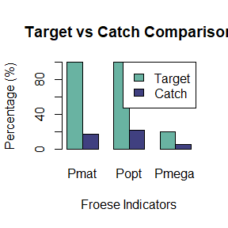

[figure not shown]

```r
# Viewing the results
results$estimated_length_par
```

```
#>                  Parameters Mean_estimate Lower_CI Upper_CI
#> Lmax_samples           Lmax      54.04398 52.01462 55.92745
#> Linf_samples           Linf      56.88840 54.75223 58.87100
#> Lmat_samples           Lmat      31.43686 29.20746 33.80848
#> Lopt_samples           Lopt      33.17129 29.94813 36.53231
#> Lopt_p10_samples   Lopt_p10      36.48841 32.94294 40.18554
#> Lopt_m10_samples   Lopt_m10      29.85416 26.95332 32.87908
```

```r
results$estimated_froese_par
```

```
#>   Parameters Mean_froese  Lower_CI Upper_CI
#> 1       Pmat   17.297845  8.943258 38.79856
#> 2       Popt   22.631373 11.080529 49.75337
#> 3      Pmega    5.905665  1.642441 15.09695
```

```r
results$forese_ind_vs_target
```

```
#>   Parameters Froese_catch Froese_tar
#> 1       Pmat    17.297845        100
#> 2       Popt    22.631373        100
#> 3      Pmega     5.905665         20
```

```r
results$Total_ind
```

```
#> [1] 5789
```

```r
results$LM_ratio
```

```
#> Lmat_samples
#>    0.9477131
```

```r
results$Pobj
```

```
#> [1] 45.83488
```

### Explaination of Output

The function returns a list with the following components saved in three different sheet of excel file:

## Function (iii): FishSS

The **FishSS** function evaluates stock status using criteria based on the estimated parameters by FishPar.

### Arguments

- **data**: A data frame containing the necessary columns for stock status calculation according to Cope and Punt (2009).
- **LM_ratio**: A numeric value representing the length at maturity ratio.
- **Pobj**: A numeric value representing the percentage objective.
- **Pmat**: A numeric value representing the percentage of mature fish.
- **Popt**: A numeric value representing the percentage of optimally sized fish.

### Example with CPdata

```r
# Load the stock status criteria data
cpdata_path <- system.file("exdata", "cpdata.xlsx", package = "aLBI")
print(cpdata_path) #check if the path exist
```

```
#> [1] "C:/Users/User/AppData/Local/Temp/RtmpE3BnKz/Rinst429445537cb6/aLBI/exdata/cpdata.xlsx"
```

```r
if (cpdata_path == "") {
  stop("The required file cpdata.xlsx is missing. Please check the inst/extdata directory.")
}
# loading the cope and punt table
cpdata <- readxl::read_excel(cpdata_path)
print(cpdata)
```

```
#> # A tibble: 21 × 11
#>       Tx     A     B     C     D     E     F     G     H     I     J
#>    <dbl> <dbl> <dbl> <dbl> <dbl> <dbl> <dbl> <dbl> <dbl> <dbl> <dbl>
#>  1   100     0     0     0     0     0     0     0     0   100   100
#>  2    95     0     0     0     0    22     0    11     0   100    93
#>  3    90     0     0     0     0   100    44    83    22   100    74
#>  4    85     0     0     0     0   100   100   100    67   100    63
#>  5    80     0     0     0     0   100   100   100   100    89    52
#>  6    75     0     0     0     0   100   100   100   100    74    37
#>  7    70     0     0     0     0   100   100   100   100    48    30
#>  8    65     0     0     0     0   100   100   100   100    33    22
#>  9    60     0     0     0     0   100   100   100   100    22    15
#> 10    55     0     0     0     0   100   100   100   100    11     7
#> # ℹ 11 more rows
```

```r
# Running the FishSS function
stock_status <- FishSS(data = cpdata,
                       LM_ratio = results$LM_ratio,
                       Pobj = results$Pobj,
                       Pmat = results$estimated_froese_par[1, 2],
                       Popt = results$estimated_froese_par[2, 2])

# Viewing the stock status
stock_status
```

```
#> $Target_Cols
#>     Tx  B  D
#> 1  100  0  0
#> 2   95  0  0
#> 3   90  0  0
#> 4   85  0  0
#> 5   80  0  0
#> 6   75  0  0
#> 7   70  0  0
#> 8   65  0  0
#> 9   60  0  0
#> 10  55  0  0
#> 11  50  0  0
#> 12  45  0  0
#> 13  40  0  0
```

[output cut: 18 more lines]

## Function (iv): LWR

### Arguments

- **data**: A data frame with two columns: the first for length, the second for weight.
- **log_transform**: Logical. Whether to apply a log-log transformation to the variables. Default is TRUE.
- **point_col**: Color of the data points. Default is black.
- **line_col**: Color of the regression line. Default is red.
- **shade_col**: Color for the confidence interval ribbon. Default is red.
- **point_size**: Size of the data points. Default is 2.
- **line_size**: Size of the regression line. Default is 1.
- **alpha**: Transparency for the confidence interval ribbon. Default is 0.2.
- **main**: Title of the plot. Default is “Length-Weight Relationship”.
- **xlab**: Optional. Custom x-axis label. If , a label is generated based on log_transform.
- **ylab**: Optional. Custom y-axis label. If , a label is generated based on on log_transform.
- **save_output**: Logical. Whether to save the plot as a PDF and the model summary as a text file in the working directory. Default is TRUE.

### Example with existing LWdata

```r
# Load the stock status criteria data
LWdata_path <- system.file("exdata", "LWdata.xlsx", package = "aLBI")
print(LWdata_path) #check if the path exist
```

```
#> [1] "C:/Users/User/AppData/Local/Temp/RtmpE3BnKz/Rinst429445537cb6/aLBI/exdata/LWdata.xlsx"
```

```r
if (LWdata_path == "") {
  stop("The required file LWdata.xlsx is missing. Please check the inst/extdata directory.")
}
# loading the cope and punt table
LWdata <- readxl::read_excel(LWdata_path)
print(LWdata)
```

```
#> # A tibble: 554 × 2
#>    Length Weight
#>     <dbl>  <dbl>
#>  1   58.7   1025
#>  2   58.6   1013
#>  3   54.6   1011
#>  4   54.3    941
#>  5   54.2    946
#>  6   53     1120
#>  7   51.7    897
#>  8   51     1031
#>  9   50.5    882
#> 10   50.4    876
#> # ℹ 544 more rows
```

```r
# Running the LWR function
lwr_result <- LWR(data = LWdata,
                log_transform = TRUE,
                point_col = "black",
                line_col = "red",
                shade_col = "red",
                point_size = 2,
                line_size = 1,
                alpha = 0.2,
                main = "Length-Weight Relationship",
                xlab = NULL,
                ylab = NULL,
                save_output = TRUE)

# Viewing the stock status
lwr_result
```

```
#> $model
#>
#> Call:
#> lm(formula = y ~ x)
#>
#> Coefficients:
#> (Intercept)            x
#>      -5.211        3.006
#>
#>
#> $intercept
#> (Intercept)
#>      0.0055
#>
#> $slope
#>     x
#> 3.006
#>
#> $r_squared
#> [1] 0.9695
#>
#> $correlation_r
#>      x
#> 0.9846
#>
#> $p_value
#> [1] 0
#>
#> $plot
```

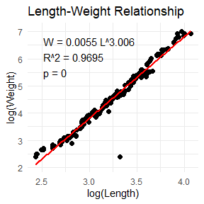

### Output

Length-Weight plot with model summery

## Conclusion

The Fish Stock Assessment package provides a robust framework for estimating biological parameters and assessing fish stock status. By following the steps outlined in this vignette, you can effectively utilize this package for your fish stock assessment needs.

## Additional Information

### Contact

For any questions or issues, please contact the package maintainer: Name: Ataher Ali Email: ataher.cu.ms@gmail.com

## Acknowledgements

I would like to express my heartfelt gratitude to my supervisor, Dr. Mohammed Shahidul Alam, for his unwavering guidance, support, and encouragement. I am also sincerely thankful to the contributors and community members for their valuable feedback and support.

This vignette provides a comprehensive guide to using the Assessment package. By following these instructions, users can effectively conduct fish stock assessments and contribute to sustainable fishery management practices.

## To read more detail

Readers are encouraged to read the article published in **Fisheries Research** of this R Package.

- Ali, A., Sarker, M. R., & Alam, M. S. (2025). Development of a simple R package (aLBI) for the estimation of stock status from the length frequency data. Fisheries Research, 288, 107467. https://doi.org/10.1016/j.fishres.2025.107467

## References

- Wang, K., Zhang, C., Xu, B., Xue, Y., & Ren, Y. (2020). Selecting optimal bin size to account for growth variability in Electronic LEngth Frequency ANalysis (ELEFAN). *Fisheries Research*, 225, 105474. https://doi.org/10.1016/j.fishres.2019.105474
- Cope, J. M., & Punt, A. E. (2009). Length‐Based Reference Points for Data‐Limited Situations: Applications and Restrictions. *Marine and Coastal Fisheries, 1*(1), 169–186. https://doi.org/10.1577/C08-025.1
- Froese, R. (2004). Keep it simple: Three indicators to deal with overfishing. *Fish and Fisheries, 5*(1), 86–91. https://doi.org/10.1111/j.1467-2979.2004.00144.x